# Carcinoma do endométrio do corpo uterino

Este trabalho prático foi desenvolvido pelos elementos Duarte Velho(pg53841),João Ferreira(pg52182), Joana Lopes(pg53498) e Ricardo Oliveira(pg53501), no âmbito da UC Extração de Conhecimentos de Dados Biológicos (2023/24), do Mestrado em Bioinformática da Escola de Engenharia da Universidade do Minho, e tem como objetivo principal analisar, através das ferramentas R e packages do Bioconductor, um conjunto de dados, acedidos a partir do GDC PortalData, relacionados com o Carcinoma Endometrial do Corpo Uterino. Será dividido em duas fases principais.

## 1ª Fase

A primeira fase deste trabalho será consituida pelas seguintes etapas: explicação dos dados, sua origem e relevância ; tarefas de preparação e de pré-processamento dos dados; sumarização dos dados (estatística descritiva, exploração com recurso a gráficos); análise estatística univariada e análise de expressão diferencial e de enriquecimento.

### Instalação e importação de packages

Nesta secção são destacados todos os packages utilizados no trabalho, que facilitam a aquisição e análise de dados ao longo do documento, tornando mais eficiente a obtenção e compreensão das informações relevantes.

```r
#install.packages("BiocManager")
#install.packages("jpeg")
#install.packages("TCGAbiolinks")
#install.packages("Biobase")
#install.packages("DESeq2")
#install.packages("ggbeeswarm")
#install.packages("genefilter")
#install.packages("pheatmap")
#install.packages("org.Hs.eg.db")
#install.packages("fgsea")
#install.packages("ggplot2")
#install.packages("xfun")
#install.packages("SummarizedExperiment")
#install.packages("factoextra")
#install.packages("Rtsne")
#install.packages("EBImage")
```

```r
#library("jpeg")
#library("TCGAbiolinks")
#library("SummarizedExperiment")
#library("DESeq2")
#library("Biobase")
#library("DESeq2")
#library("ggbeeswarm")
#library("pheatmap")
#library("org.Hs.eg.db")
#library("fgsea")
#library("ggplot2")
#library("factoextra")
#library("limma")
#library("genefilter")
#library("Rtsne")
#library("party")
#library("rpart")
#library("caret")
#library("rsample")
#library(AnnotationDbi)
#library(org.Hs.eg.db)
#library(ggplot2)
#library(tidyverse)
#library(fgsea)
```

### **1.Introdução**

#### 1.1 Enquadramento

Nos dias de hoje, o cancro é uma das principais causas de morte a nível mundial, sendo que, segundo a Organização Mundial da Saúde (OMS), em 2020, foram diagnosticados cerca de 19,3 milhões de novos casos de cancro, que resultaram na morte, de aproximadamente 10 milhões de pessoas [1]. O preocupante aumento da incidência do cancro ao longo das ultimas décadas levou ao surgimento de iniciativas, tal como a PanCancer Atlas, que visam encontrar respostas para as grandes e abrangentes questões sobre o cancro, através da análise de tumores caracterizados no conjunto de dados resultantes do projeto de The Cancer Genome Atlas (TCGA). O TCGA é um programa de genómica de referência na área do cancro que, em colaboração com o Instituto Nacional do Cancro (NCI) e o Instituto Nacional de Pesquisa do Genoma Humano (NHGRI) dos Estados Unidos, caracterizou mais de 20 mil cancros primários abrangendo 33 tipos de cancro. Os tipos de cancro selecionados para estudo cumprem requisitos tais como ter um mau prognóstico, ter um impacto geral na saúde pública, disponibilidade de amostras com a qualidade e quantidade desejadas, entre outros. (National Cancer Institute, 2022)

O cancro endometrial do corpo uterino, um dos cancros incluídos no TCGA, é o sétimo tumor maligno mais frequente no mundo e o quarto mais comum na mulher sendo a doença ginecológica maligna mais prevalente, tendo provocado em 2011 mais de 8 mil mortes [2,3]. De todos os cancros do corpo uterino mais de 83% correspondem a carcinomas do endométrio, enquanto apenas 10% dos diagnósticos são classificados como sarcomas [2]. Este tipo de cancro tem ganho maior atenção por parte da comunidade científica, uma vez que se verificou um aumento da sua incidência com a agravante de que a taxa de sobrevivência aos 5 anos é consideravelmente menor, em comparação com o ano de 1975, passando de 88% para cerca de 84%, em 2006, indicando um aumento na mortalidade [3]. A taxa de sobrevivência está fortemente correlacionada com o estádio da doença aquando do diagnóstico, sendo que para pacientes no estádio inicial se considera curável atingindo cerca de 96% de sobrevivência. No entanto, para fases mais avançadas e de alto grau, é considerado letal reduzindo drasticamente a taxa de sobrevivência de 96% para 17%.(Costa & Cunha, n.d.)

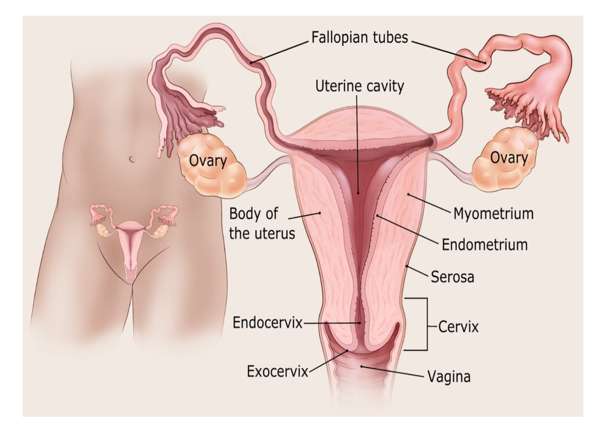

Fig 1- Anatomia do sistema reprodutor feminino (Adaptdado de American Society Cancer)

#### 1.2. Objetivo

Com base na problemática apresentada, este trabalho tem como objetivo analisar o perfil transcriptómico de células endometeriais do corpo uterino de pacientes diagnosticados com cancro para determinadas condições descritas nos metadados, de modo a realizar a análise da expressão diferencial com o intuito de compreender qual o efeito do fator no perfil transcriptómico das células e como esse perfil se traduz na gravidade da doença observada. Os dados utilizados neste trabalho estão disponíveis no [GDC DataPortal](https://shorturl.at/fmpJ5).

### **2.Extração dos dados de transcriptómica e respetivos metadados da base de dados**

#### 2.1. Obtenção dos dados

```r
#query_UCEC = GDCquery(
#  project = "TCGA-UCEC",
#  data.category = "Transcriptome Profiling",
#  data.type = "Gene Expression Quantification",
#  workflow.type = "STAR - Counts"
#)
#GDCdownload(query=query_UCEC)
#rna_seq_UCEC = GDCprepare(query = query_UCEC, save = TRUE, save.filename = "mRNA_TCGA-UCEC.rda")
rna_seq_UCEC = get(load("mRNA_TCGA-UCEC.rda"))
```

A função **GDCquery()** é utilizada para realizar a query à base dados. Nesta função são definidos vários parâmetros que permitem filtrar o data set que posteriormente vai ser descarregado. O parâmetro “project” corresponde ao id atribuído ao tipo de cancro de modo a apenas considerar a informação disponível referente ao carcinoma endométrio do corpo uterino. A “data.category” é usado para especificar a categoria de dados que se pretende selecionar, neste caso, como pretendemos realizar a análise da transcriptómica selecionou-se a categoria “Transcriptome Profiling” para selecionar os dados relacionados com o perfil de expressão de genes. De entre os dados do perfil de expressão de genes restringiu-se apenas aos dados referentes à quantificação da expressão de genes definindo “data.type” como Gene expression quantification. Por fim, indicou-se o tipo de análise da expressão genética desejada, optando-se por recorrer ao START-Counts. Este workflow indica que o algoritmo utilizado para a contagem da expressão genética a partir do alinhamento das sequências foi realizada com a ferramenta STAR.

A função **GDCdownload()** é utilizada para realizar o download dos dados consoante a query realizada e estabelecida na função anterior. Em seguida, recorreu-se à função **GDCprepare()** com o intuito de gerar um objeto “SummarizedExperiment” de modo a compilar a informação descarregada num único objeto de modo a facilitar a análise dos dados. É de notar que a função também permite gravar os dados em formato “rdata” de modo a facilitar o carregamento dos dados através da função **load()**. É importante referir que a utilização deste workflow permite o download simultâneo quer dos dados da expressão genética quer dos metadados associados às amostras e aos genes.

#### 2.2. Análise inicial dos dados

Nesta fase procedeu-se à exploração incial dos dados de forma a perceber a dimensão dos dados correspondentes à expressão genética bem como dos metadados.

```
## Class of rna_seq_UCEC: RangedSummarizedExperiment
```

[output not shown]

```
## First 5 column names of rna_seq_UCEC: TCGA-FI-A3PX-01A-11R-A22K-07, TCGA-BG-A221-01A-21R-A157-07, TCGA-EY-A1GK-01A-11R-A13S-07, TCGA-BG-A2AE-01A-11R-A16F-07, TCGA-AX-A1CE-01A-11R-A137-07
```

```
## First 5 row names of rna_seq_UCEC: ENSG00000000003.15, ENSG00000000005.6, ENSG00000000419.13, ENSG00000000457.14, ENSG00000000460.17
```

```
## Class of linhas_metadados: DFrame
##  Class of amostras_metadados: DFrame
##  Dimensions of linhas_metadados: 60660 x 10
##  Dimensions of amostras_metadados: 589 x 78
##  First 5 column names of linhas_metadados: source, type, score, phase, gene_id
##  First 5 column names of amostras_metadados: barcode, patient, sample, shortLetterCode, definition
```

Através da análise feita acima é possível verificar que o nosso dataset é um objeto **SummarizedExperiment** que possui 60660 linhas e 589 colunas. Com a extração dos metadados associados às linhas podemos concluir que as linhas do objeto correspondem aos genes, sendo que, para cada gene, existem 10 metadados associados incluindo o gene_id que corresponde a um código único utilizado pela base de dados Ensembl para a identificação dos varios genes. Por outro lado, as colunas possuem 78 metadados que possibilitam a caracterização das 589 amostras utilizadas neste estudo permitindo analisar o impacto que as diferentes características possuem nos dados de expressão genética. É importante referir que os metadados associados às colunas passam a ter uma apresentação diferente, isto é, as linhas passam a ser identificadas com o id da amostra enquanto no objeto original as linhas são identicadas pelo id do gene.

#### 2.3. Preparação e pre-processamento dos dados

Nesta etapa preparamos o dataset para ser, posteriormente, submetido a análise de expressão diferencial e de enriquecimento. Para esse efeito, optamos por separar os dados referentes à expressão genética e a informação relativa aos metadados do objeto inicial para depois realizar a filtragem dos dados.

```r
#extração da informação da expressão de genes
geneExp = SummarizedExperiment::assay(rna_seq_UCEC)
```

Com o package **SummarizedExperiment** armazenamos os dados de contagens de sequenciamento de RNA, bem como outros tipos de dados experimentais ómicos, juntamente com metadados relevantes. Esses dados de expressão genética extraídos são armazenados na variável geneExp. O comando **assay()** é usado para extrair a matriz de contagens (ou matriz de expressão) do objeto SummarizedExperiment. Esta matriz contém os dados numéricos de expressão para cada gene em cada amostra, que são essenciais para análises subsequentes, como normalização, análise de expressão diferencial, e outras análises ômicas.

#### 2.4. Pre-processamento e filtragem dos metadados

Com o intuito de fazer uma filtragem dos metadados, uma vez que é comum a existência de valores omissos, procedeu-se procedeu-se à diminuição do número de colunas associadas aos metadados, eliminando-se as colunas que possuem mais de 10% de valores omissos. Com esta abordagem vamos eliminar metadados que, por possuirem um número de NAs que definimos como limite, não constituem interesse para o nosso estudo. Assim, removemos as colunas dos metadados onde havia mais de 60 elementos como: “not/Not reported/Reported” e/ou “NA.

```r
# remoção de colunas com mais de 10% de valores omissos
rm_not_reported = which(sapply(amostras_metadados,function(x) sum(x == "not reported", na.rm = TRUE)) > 60)
rm_Not_Reported = which(sapply(amostras_metadados,function(x) sum(x == "Not Reported",na.rm = TRUE)) > 60)
rm_nas = which(sapply(amostras_metadados, function(x) sum(is.na(x))) > 60)
amostras_meta_reduzido = amostras_metadados[, -c(rm_not_reported, rm_Not_Reported, rm_nas)]
dim(amostras_meta_reduzido)
```

```
## [1] 589  50
```

Com esta filtragem obtivemos 50 colunas, em vez das 78 iniciais.É possível realizar uma filtragem ainda mais profunda dos metadados, porém estabeleceu-se nesta fase inicial uma percentagem fixa de valores omissos a eliminar.

#### 2.5. Análise Descritiva e Exploratória

Para o nosso estudo, de entre as 50 colunas de metadados filtradas, selecionamos 4 variáveis de caraterísticas distintas, nomeadamente as colunas “vital_status”, “primary_diagnosis”, “age_at_index”, “figo_stage”, procedendo ainda a uma transformação desta última coluna que será explicada adiante.

#### - Estado Vital

A coluna “vital_status”, incorpora uma variável nominal e dá-nos informações sobre a sobrevivência do paciente com cancro e apresenta 3 categorias possívies: “Alive”, “Dead”, “NA”. Neste caso verificamos que, no momento de recolha dos dados, dos 589 pacientes, aproximadamente 81% estavam vivos e 16% tinham falecido, acerca dos restantes não havia informação disponível, sendo reportados como “NAs”.

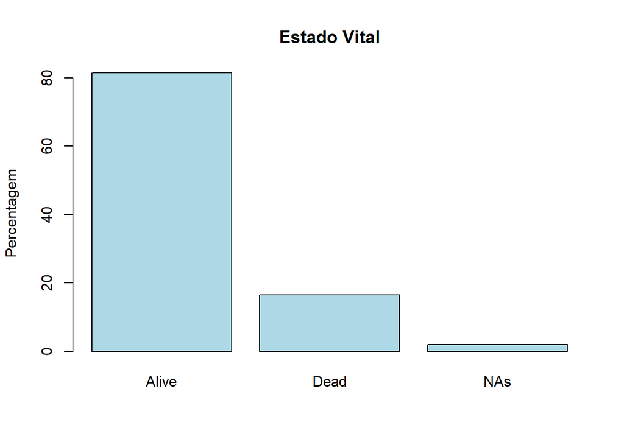

#### - Diagnóstico Primário

A coluna “primary_diagnosis”, corresponde a uma variável nominal, e descreve o diagnóstico histológico do paciente, de acordo com a Classificação Internacional de Doenças para Oncologia (International Classification of Diseases for Oncology, ICD-O) da Organização Mundial da Saúde. Apresenta 8 categorias possíveis “Adenocarcinoma, NOS”,“Carcinoma, undifferentiated, NOS”,“Clear cell adenocarcinoma, NOS”,“Endometrioid adenocarcinoma, NOS”,“Endometrioid adenocarcinoma, secretory variant”,“Papillary serous cystadenocarcinoma”,“Serous cystadenocarcinoma, NOS”,“Serous surface papillary carcinoma”. A desginação “NOS”, Not Otherwise Specified, apenas indica que com base nas informações disponíveis, um determinado tipo de cancro não pode ser encaixado noutra categoria mais específica. Verificamos que os dados vão de encontro à literatura, identificando o adenocarcinoma do endométrio como prevalente neste estudo, com cerca de 71.8% de pacientes diagnosticados com este tipo de cancro do corpo uterino. Logo de seguida temos 24.3% de pacientes com cistoadenocarcinomas serosos e 3.9% com outros tipos de cancro que agrupamos na categoria “Outros”, incluindo os casos em que não se sabe a categoria(“NA”).

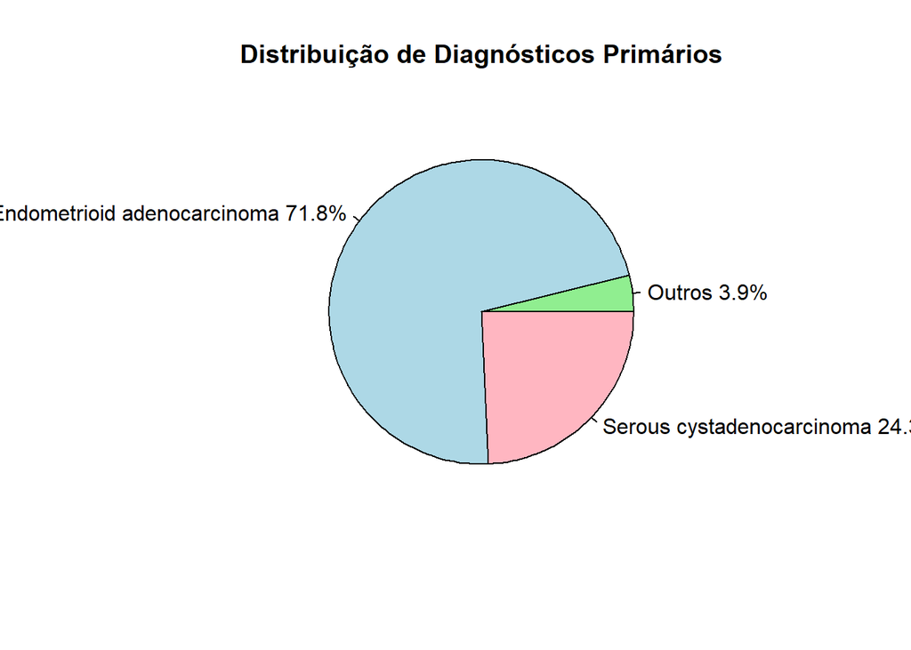

#### - Estádio FIGO

A coluna “figo_stage”, incorpora uma variável ordinal que representa o estádio do cancro, nomeadamente no que diz respeito à sua extensão, especialmente se a doença se espalhou do local original para outras partes do corpo, conforme descrito pelos estádios da Federação Internacional de Ginecologia e Obstetrícia (FIGO) [4]. Originalmente, esta classificação está dividia em 4 estádios principais, nomeadamente, estádio I onde o tumor está confinado ao corpo uterino, estádio II onde já existe envolvimento do cérvix/colo uterino, estádio III que representa um atingimento de estruturas adjacentes do mesmo orgão como por exemplo os gânglios linfáticos da zona pélvica e, por último, o estádio IV onde já existem metásteses noutros orgãos como por exemplo no intestino. Para além desta classificação em 4 estádios gerais, cada um destes estádios se encontra subdividido em dois ou mais estádios consoante a extensão a outras estrututras. Neste estudo, para conseguirmos visualizar os dados de forma mais eficiente, e dado o objetivo deste trabalho, decidimos proceder a uma transformação desta coluna, agrupando os diferentes sub-estádios nas suas 4 categorias principais. Desta forma, esta variável toma 4 níveis “STAGE I”, “STAGE II”, “STAGE III” e “STAGE IV”, sendo que 60.3% das amostras são de tumores em “STAGE I”, 9.2% em “STAGE II”, 23.3% em “STAGE III”, 5.3% em “STAGE IV” e exitem ainda 2% de amostras que não possuem classificação quanto ao estádio. Ou seja, mais de metade dos tumores em estudo são confinados ao corpo uterino, e uma parte considerável correspondem a tumores mais agressivos, com atingimento de estruturas adjacentes ao orgão reprodutor feminino (23.3%) ou com atingimento de outros orgãos (5.3%).

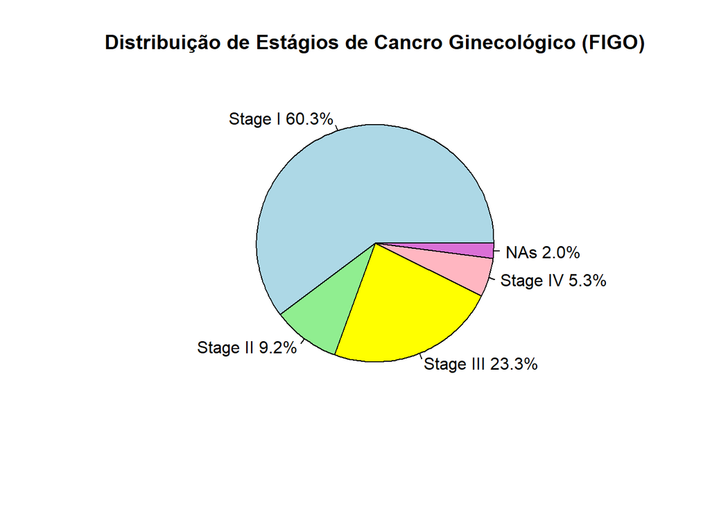

#### - Idade dos Pacientes

```
##    Min. 1st Qu.  Median    Mean 3rd Qu.    Max.    NA's
##   31.00   57.00   64.00   63.85   71.00   90.00      15
```

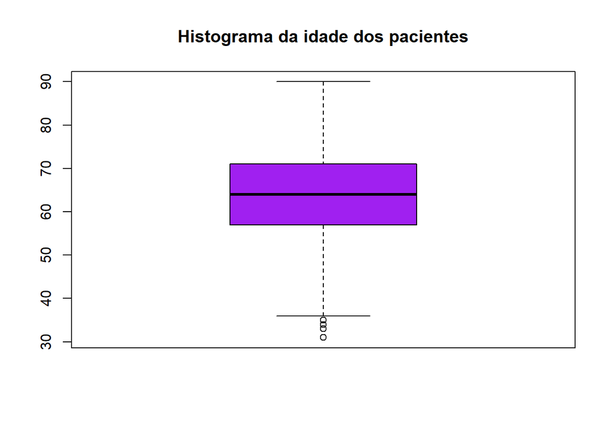

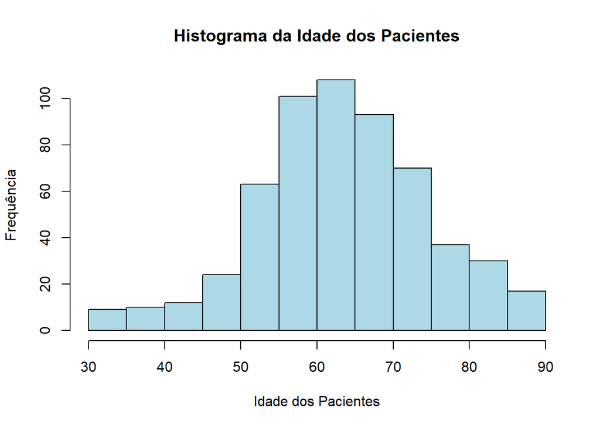

Dado que verficamos a presença de alguns NAs, na fase de realização dos testes de hipóteses, decidimos eliminar as linhas, ou seja, os pacientes, sobre os quais não tínhamos informações relativas aos metadados selecionados. Esta trasnformação culminou num total de 574 pacientes em estudo em vez dos 589 iniciais.

#### 3.3. Testes de hipótese

###### **Nota:** para todos os testes estatísticos abaixo realizados, considere-se um valor de prova igual a 0.05.

Ainda dentro da análise exploratória dos dados, através do boxplot “Idade do Paciente por Estádio FIGO” conseguimos, visualmente, constatar que a mediana das idades em pacientes com tumor no estádio IV é maior que as restantes, o que pode indicar uma relação entre a idade avançada e o estádio do tumor no que diz respeito à sua gravidade. Entre os restantes estádios não se verifica, visualmente, uma diferença tão notória na mediana.

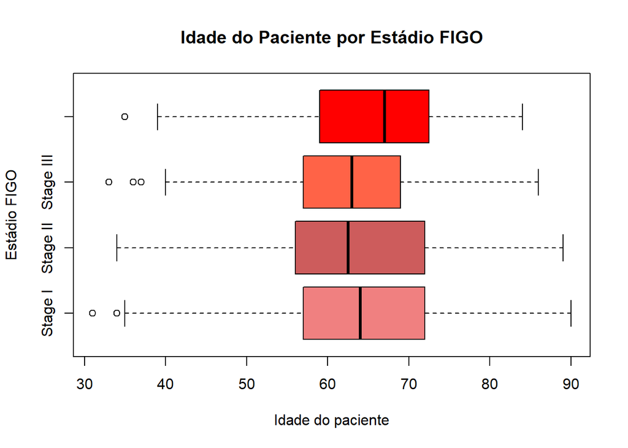

Passando aos testes estatísticos, para as hipóteses definidas como:

H0: Não existem diferenças significativas na média das idades dos pacientes entre os diferentes estádios. H1: Existem ou não diferenças significativas na média das idades dos pacientes entre os diferentes estádios.

através do **shapiro.test()** verificamos que os dados da variável “age_at_index” não são normais (p.value<0.05). No entanto, através da análise do Q-Q Plot, com sobreposição da linha qqline, verificamos que os pontos estão, na sua maioria, sobrepostos à linha diagonal e apenas as extremidades se afastam abaixo e acima da diagonal. Para além disso, estamos perante um grande volume de dados (n=574), ou seja, de acordo com o teorema do limite central, podemos aceitar a normalidade dos dados apesar de o valor de p-value do teste de shapiro nos levar a rejeitar a hipótese nula. Garantindo a normalidade e a homogenidade das variâncias, procedemos à análise **anova one way** para verificarmos se existem ou não diferenças significativas na média das idades dos pacientes entre os diferentes estádios e obtivemos um valor de prova de 0.722, o que nos leva a não rejeitar a hipótese nula, ou seja, não há diferenças significativas na média das idades dos pacientes entre os diferentes estádios.

```
##
##  Shapiro-Wilk normality test
##
## data:  metados_sem_nas$age_at_index
## W = 0.99153, p-value = 0.002306
```

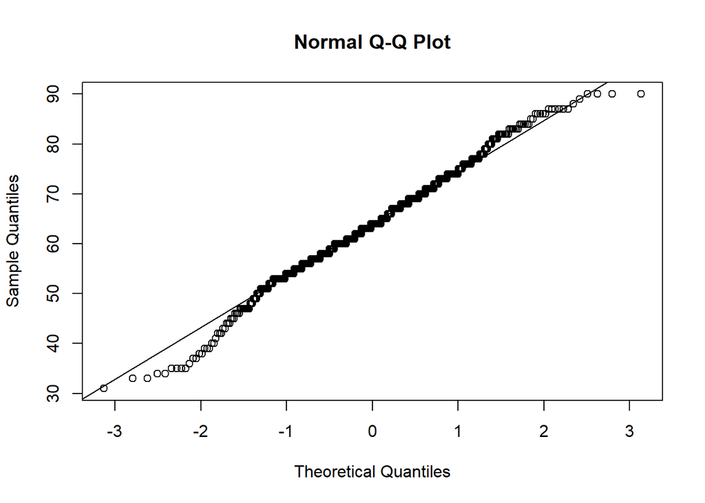

```
##
##  Bartlett test of homogeneity of variances
##
## data:  metados_sem_nas$age_at_index by metados_sem_nas$figo_stage
## Bartlett's K-squared = 3.4361, df = 3, p-value = 0.3291
```

```
##                             Df Sum Sq Mean Sq F value Pr(>F)
## metados_sem_nas$figo_stage   3    167   55.51   0.443  0.722
## Residuals                  570  71349  125.17
```

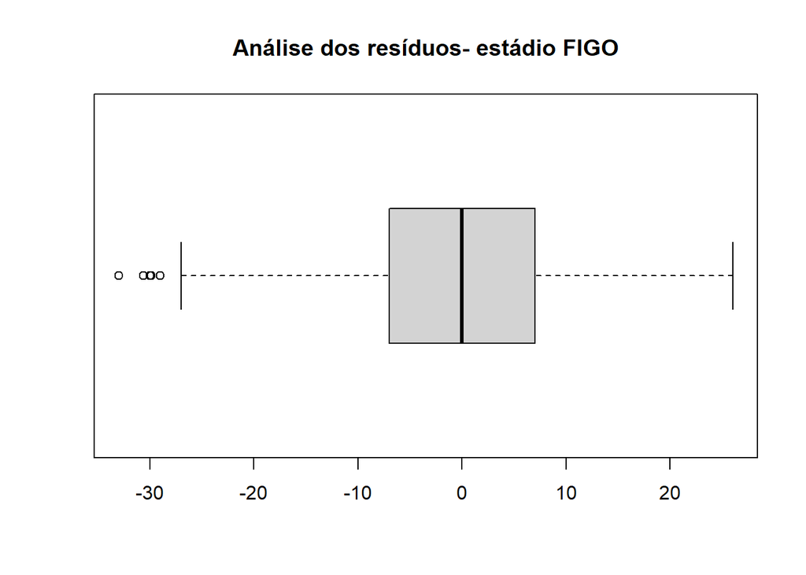

Ainda assim, procedemos à realização do teste não paramétrico **kruskal.test()** para vermos se os resultados seriam os mesmos e, mais uma vez, obtivemos um valor de prova de 0.6632 que não nos permite rejeitar a hipótese de que não há diferenças significativas na média das idades dos pacientes entre os diferentes estádios.

```r
kruskal.test(metados_sem_nas$age_at_index~metados_sem_nas$figo_stage) # teste não parametrico
```

```
##
##  Kruskal-Wallis rank sum test
##
## data:  metados_sem_nas$age_at_index by metados_sem_nas$figo_stage
## Kruskal-Wallis chi-squared = 1.5834, df = 3, p-value = 0.6632
```

No que diz respeito ao estado de sobrevivência dos pacientes, vital_status, visualmente é transmitida a ideia de que os pacientes que já faleceram tinham uma idade mais avançada. Através do teste anova one way,para as hipóteses definidas como:

H0: Não existem diferenças significativas na média das idades dos pacientes entre os diferentes estados de vida. H1: Existem ou não diferenças significativas na média das idades dos pacientes entre os diferentes estados de vida.

verificamos que a hipótese nula é rejeitada ( p value= 6.13e-05), ou seja, existem diferenças estatisticamente significativas entre a idade dos pacientes nos diferentes grupos “Alive” e “Dead”.

```
##
##  Bartlett test of homogeneity of variances
##
## data:  metados_sem_nas$age_at_index by metados_sem_nas$vital_status
## Bartlett's K-squared = 0.20668, df = 1, p-value = 0.6494
```

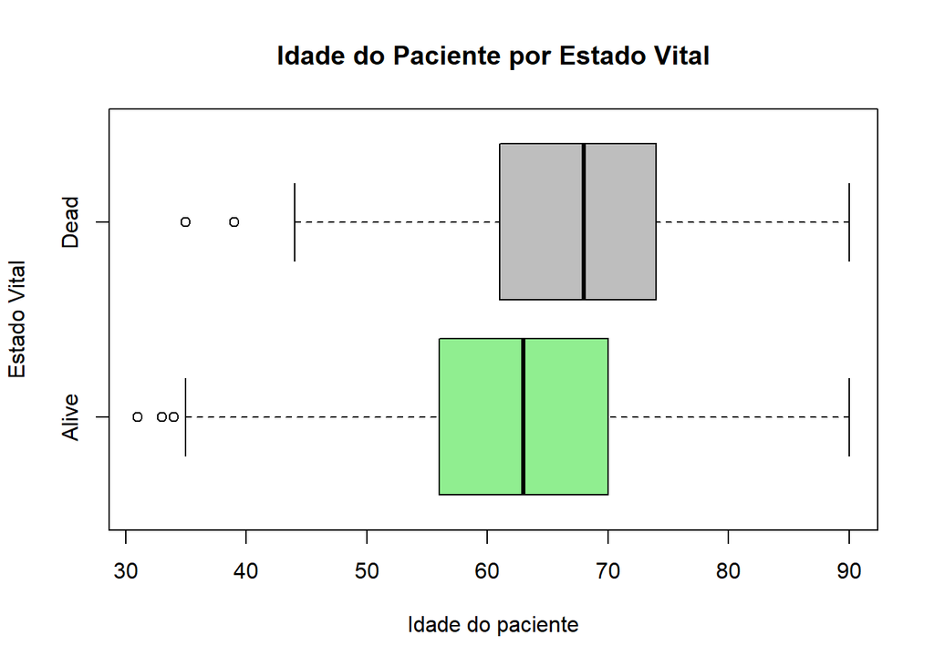

```
##                               Df Sum Sq Mean Sq F value   Pr(>F)
## metados_sem_nas$vital_status   1   1982  1982.0    16.3 6.13e-05 ***
## Residuals                    572  69534   121.6
## ---
## Signif. codes:  0 '***' 0.001 '**' 0.01 '*' 0.05 '.' 0.1 ' ' 1
```

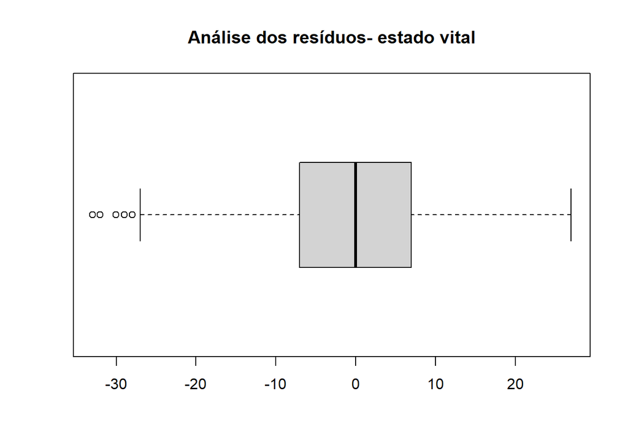

Realizamos também para este caso o teste não paramétrico kruskal.test() e obtivemos um valor de prova de 0.0001071 que nos permite rejeitar a hipótese de que não há diferenças significativas na média das idades dos pacientes entre os diferentes estados de vida (“Alive” e “Dead”).

```
##
##  Kruskal-Wallis rank sum test
##
## data:  metados_sem_nas$age_at_index by metados_sem_nas$vital_status
## Kruskal-Wallis chi-squared = 15.008, df = 1, p-value = 0.0001071
```

### **3.Análise de expressão diferencial e enriquecimento**

#### 3.1.Análise de expressão diferencial

Com o intuito de proceder à análise dos genes que se encontram diferencialmente expressos no tumor “Endometrioid adenocarcinoma, NOS” em função do estado vital do paciente em estudo procedeu-se ao pré-processamento dos dados de modo a facilitar e otimizar a análise diferencial reduzindo o tempo e os recursos computacionais necessários. Numa primeira fase realizou-se a filtragem das amostras que são descritas nos metadados como tendo diagnóstico primário de “Endometrioid adenocarcinoma, NOS”, já que apenas estas amostras representam relevância para este estudo. Em seguida, avaliou-se a eventual presença de valores omissos ao nível da coluna do estado vital e, uma vez que não existem valores omissos, transformou-se o metadado “vital_status” em fator, visto que a análise de expressão diferencial realizada pelo package DESeq2 recomenda a utilização de fatores ao invés de caracteres.

```r
dados_sem_nas = rna_seq_UCEC[,!is.na(rna_seq_UCEC$primary_diagnosis)]
amostras_EA = dados_sem_nas$primary_diagnosis == "Endometrioid adenocarcinoma, NOS"
dados_EA = dados_sem_nas[,amostras_EA]
dim(dados_EA)
```

```
## [1] 60660   423
```

```r
library(DESeq2)
gene_exp_filtrado = dados_EA[,!is.na(dados_EA$vital_status)]
gene_exp_filtrado$vital_status = factor(gene_exp_filtrado$vital_status)
ddsSE = DESeqDataSet(gene_exp_filtrado, design = ~ vital_status)
dim(ddsSE)
```

```
## [1] 60660   423
```

```r
ddsSE = ddsSE[rowSums(counts(ddsSE)) > 0, ]
dim(ddsSE)
```

```
## [1] 57461   423
```

```r
genes_manter = rowSums(counts(ddsSE) >= 10) >= 3
ddsSE = ddsSE[genes_manter, ]
dim(ddsSE)
```

```
## [1] 34042   423
```

```r
ddsSE_norm = DESeq(ddsSE)
resultados = results(ddsSE_norm, alpha = 0.05)

summary(resultados) # sumario dos resultados do teste de expressão diferencial
```

```
##
## out of 34042 with nonzero total read count
## adjusted p-value < 0.05
## LFC > 0 (up)       : 3682, 11%
## LFC < 0 (down)     : 1194, 3.5%
## outliers [1]       : 0, 0%
## low counts [2]     : 0, 0%
## (mean count < 0)
## [1] see 'cooksCutoff' argument of ?results
## [2] see 'independentFiltering' argument of ?results
```

```r
sum(resultados$padj < 0.05, na.rm=TRUE) # número total de genes diferencialmente expressos
```

```
## [1] 4876
```

Em seguida procedeu-se à utilização da função **DESeq()** para realizar os testes de expressão diferencial. Esta função realiza 4 etapas essências para garantir a robustez dos testes realizados. A primeira etapa corresponde à estimativa de fatores de tamanho para cada amostra, sendo estes utilizados para normalizar as contagens de expressão genética, tendo em consideração as diferenças nas profundidades de sequenciamento entre as amostras, sendo essencial para remover enviesamento técnicos. Posteriormente, a função realiza a estimativa das dispersões que corresponde às variações biológica e técnica dos dados de expressão genética. Após a estimativa dos valores de dispersão, o modelo estatísticos é ajustado aos dados, com o intuito de se testar a expressão diferencial para o modelo criado no objeto DESeqDataSet, sendo que o teste padrão utilizado pela ferramenta é o **test Wald**, no entanto pode-se utiliar o teste de log-verossimilhança (LRT). Por fim, a função deteta e substitui outliers, isto é, genes com contagens muito altas ou muito baixas em comparação com a previsão do modelo, de modo a melhorar a robustez dos resultados

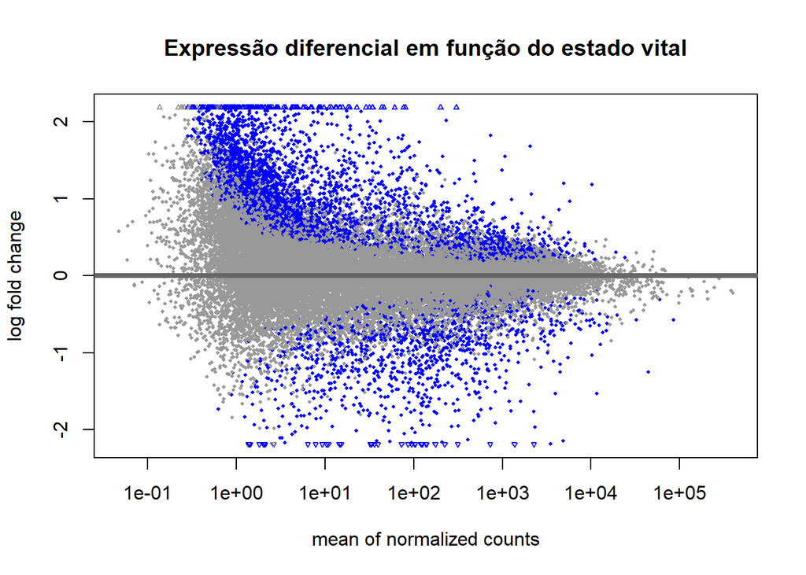

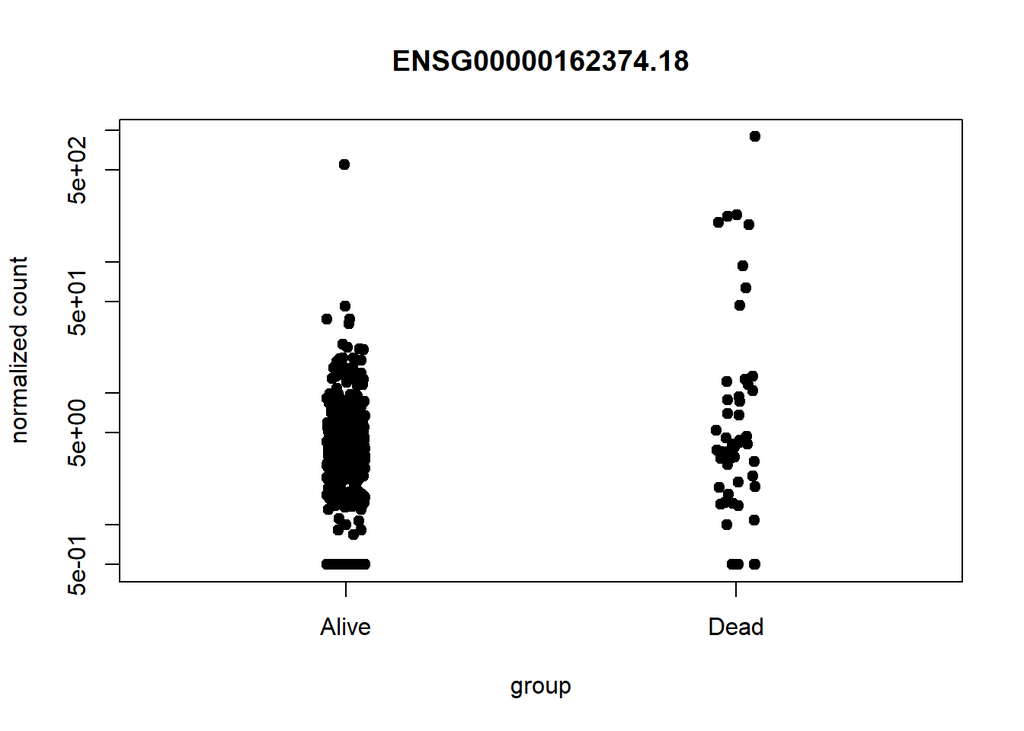

```
## log2 fold change (MLE): vital status Dead vs Alive
## Wald test p-value: vital status Dead vs Alive
## DataFrame with 1 row and 6 columns
##                     baseMean log2FoldChange     lfcSE      stat     pvalue
##                    <numeric>      <numeric> <numeric> <numeric>  <numeric>
## ENSG00000162374.18   8.91877        3.21027  0.242816    13.221 6.6363e-40
##                           padj
##                      <numeric>
## ENSG00000162374.18 2.25913e-35
```

Em seguida, optou-se por analisar o comportamento de um gene indivual, tendo se escolhido o gene que apresenta o menor valor de padjust indicando que será o gene que mais se encontra diferencialmente expresso. Pela análise do gráfico, verifica-se que o grupo “alive” possui menor variação na contagem normalizada do que o grupo “dead”, o que leva a que a média do grupo “Dead” seja superior à média do grupo “Alive”. Esta informação é corroborada pelas estatísticas produzidas para este gene em que o valor de log2FoldChange, por ser positivo indica que a classe Dead se encontra sobreexpressa, no entanto no gráfico essa conclusão fica dificultada e, para além disso, ambas as classes paracem apresentar o mesmo comportamento. Tal como observado no gráfico MA plot, este gene apresenta níveis de expressão baixos o que faz com que a variabilidade da expressão seja fortemente afetada por pequnas variações na contagem. Em adição, este “falso positivo”, pode também ser resultado do facto de que cerca de 80% das amostras analisadas correspondem ao estado vivo enquanto que apenas 16% ao estado morto, levando a que a media das contagens para o estado morto seja, também, mais influenciada pela variação das contagens. Para além disso, uma breve pesquisa em artigos de estudo de cancro, afirmam que, atualmente, não existem evidências científicas que comprovem que o gene ELAVL4 (ENSG00000162374.18), possua impacto direto na progessão do estadio do cancro, na formação de metasteses ou com a gravidade do tumor, sendo que, para o tumor endometrial, ainda não existem estudos que incidam sobre este gene, reforçando portanto que o facto deste gene ser considerado diferencialmente expresso pode ser o resultado de limitações técninas e não pelo impacto biológico que este gene apresenta nas amostras analisadas sendo necessários estudos posteriores.

#### 3.2.Análise de enriquecimento

Esta fase ainda se encontra em análise, sendo que o código R que nos permitirá tirar as conclusões finais se encontra nos scripts auxiliares presentes no repositório.

### Bibliografia

1. Sung H, Ferlay J, Siegel RL, Laversanne M, Soerjomataram I, Jemal A, Bray F. Global Cancer Statistics 2020: GLOBOCAN Estimates of Incidence and Mortality Worldwide for 36 Cancers in 185 Countries. CA Cancer J Clin. 2021 May;71(3):209-249. : 10.3322/caac.21660.
2. Creasman WT, Odicino F, Maisonneuve P, Quinn MA, Beller U, Benedet JL, Heintz A, Ngan H, Pecorelli S. Carcinoma of the Corpus Uteri. Int J Gynaecol Obstet. 2006 Nov;95 Suppl 1:S105-S143. : 10.1016/S0020-7292(06)60031-3.
3. Leslie KK, Thiel KW, Goodheart MJ, De Geest K, Jia Y, Yang S. Endometrial cancer. Obstet Gynecol Clin North Am. 2012 Jun;39(2):255-68. : 10.1016/j.ogc.2012.04.001.
4. Bhatla, N., Berek, J.S., Cuello Fredes, M., Denny, L.A., Grenman, S., Karunaratne, K., Kehoe, S.T., Konishi, I., Olawaiye, A.B., Prat, J. and Sankaranarayanan, R. Revised FIGO staging for carcinoma of the cervix uteri†. 2019 Jan; 145: 129-135. : 10.1002/ijgo.12749